# Analysis of the Stroop test performance.

by Mark Ayzenshtadt

## 0. The data.

The data consists of the performance in the Stroop test for 24 participants.  
Each row shows result in seconds in the congruent and incongruent tasks for one participant.

```python
import pandas as pd
import numpy as np
import scipy.stats
from ggplot import *
%matplotlib inline
data = pd.read_csv('stroopdata.csv')
print data
```

```
    Congruent  Incongruent
0      12.079       19.278
1      16.791       18.741
2       9.564       21.214
3       8.630       15.687
4      14.669       22.803
5      12.238       20.878
6      14.692       24.572
7       8.987       17.394
8       9.401       20.762
9      14.480       26.282
10     22.328       24.524
11     15.298       18.644
12     15.073       17.510
13     16.929       20.330
14     18.200       35.255
15     12.130       22.158
16     18.495       25.139
17     10.639       20.429
18     11.344       17.425
19     12.369       34.288
20     12.944       23.894
21     14.233       17.960
22     19.710       22.058
23     16.004       21.157
```

## 1. The independent and dependent variables.

Independent variable: Congruency (whether the color of the word matches the word).  
Dependent variable: Performance (measured by the time it takes to name the colors of all the words).

## 2. Set of hypotheses for the task.

It is important to notice that the samples are dependent (paired) - both tasks are done by the same person.  
To test whether congruency matters, we will test whether the samples come from the same distribution. So, the null hypothesis is: "The two samples come from the same distributions."  
The alternative hypothesis: "The two samples come from different distributions."

To choose the test that we want to use, we will test the two samples for normality. We will do it with the scipy.stats' "Normaltest", which is based on the analysis of skew and kurtosis of the distribution, and also with the Shapiro-Wilk test.  
If both samples will pass the normality test, we will use the paired Student's T-test, and if either sample does not pass - the Wilcoxon signed-rank test.

## 3. Descriptive statistics regarding this dataset.

```python
print data.describe()
print '\nCongruent median:',data.Congruent.median()
print 'Incongruent median:', data.Incongruent.median()
print '\nCongruent range: ', (data.max() - data.min()).Congruent
print 'Incongruent range: ', (data.max() - data.min()).Incongruent
```

```
       Congruent  Incongruent
count  24.000000    24.000000
mean   14.051125    22.015917
std     3.559358     4.797057
min     8.630000    15.687000
25%    11.895250    18.716750
50%    14.356500    21.017500
75%    16.200750    24.051500
max    22.328000    35.255000

Congruent median: 14.3565
Incongruent median: 21.0175

Congruent range:  13.698
Incongruent range:  19.568
```

We can see that means, medians, ranges and standard deviations are very different between the congruent and incongruent tasks.

## 4. Visualizations that show the distribution of the sample data.

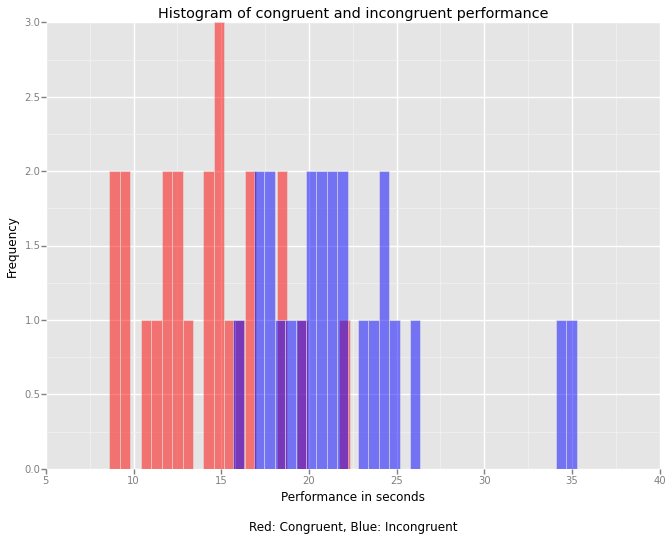

```python
print ggplot(aes(), data = data) \
    + geom_histogram(aes('Congruent'), alpha = 0.5, fill = 'red', binwidth = 0.6) \
    + geom_histogram(aes('Incongruent'), alpha = 0.5, fill = 'blue', binwidth = 0.6) \
    + xlab('Performance in seconds\n\nRed: Congruent, Blue: Incongruent') \
    + ylab('Frequency') \
    + ggtitle ('Histogram of congruent and incongruent performance')
```

Here we can see that the incongruent sample is clearly shifted to the right, comparing to the congruent.

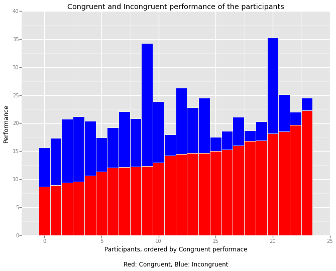

```python
print ggplot(aes(), data = data.sort('Congruent')) \
    + geom_bar(aes(data.index,'Incongruent'),stat = 'identity', fill = 'blue') \
    + geom_bar(aes(data.index,'Congruent'),stat = 'identity', fill = 'red') \
    + xlim(-2, 25) \
    + xlab('Participants, ordered by Congruent performace\n\nRed: Congruent, Blue: Incongruent') \
    + ylab('Performance') \
    + ggtitle('Congruent and Incongruent performance of the participants')
```

This plot shows the difference between congruent and incongruent performance (the blue part of the bar shows the difference between the results).  
Participants are ordered by their congruent performance.  
We can see that the participants, who did worse in the congruent test, were showing lower difference between the tests.

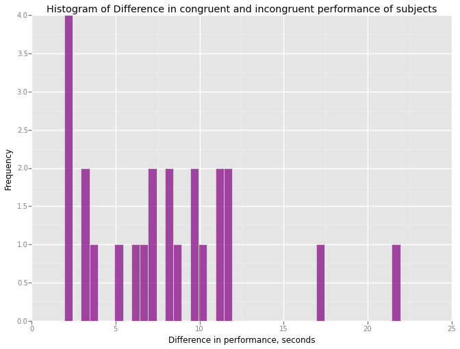

```python
print ggplot(aes(0), data = pd.DataFrame(data.Incongruent - data.Congruent)) \
    + geom_histogram(fill = 'purple', alpha = 0.7, binwidth = 0.5) \
    + xlab('Difference in performance, seconds') \
    + ylab('Frequency') \
    + ggtitle ('Histogram of Difference in congruent and incongruent performance of subjects')
```

From this plot we can conclude that the differences between the tests are not normally distributed (skewed to the right), and in most cases, the difference between the two results is somewhere between 3 and 12 seconds.  
We also see that there is no participant who performed in the incongruent scenario better than in the congruent.  
To infer this relation onto the population, we need to confirm it with a proper test.  
We also see two outliers - participants #14 and #19, who have the difference in time between tasks of about 17 and 22 seconds, respectively.  
These two participants did not show particularly good performance in the congruent task, and it is plausible that they performed much worse in the incongruent one.  
2 outliers out of 24 (8%) is a reasonable amount and can be explained by variation in the populaton.

```
Coefficient of determination:  0.123776979742
```

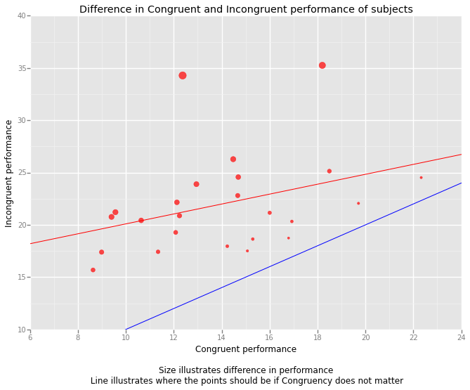

```python
slope, intercept, r_value, _, _ = scipy.stats.linregress(data.Congruent, data.Incongruent)
print "Coefficient of determination: ", r_value**2
print ggplot(data, aes()) \
    + geom_point(aes(x = 'Congruent',y = 'Incongruent'), color = 'red', size = (data.Incongruent - data.Congruent)*5, alpha = 0.7) \
    + geom_abline(intercept = 0, slope = 1, color = 'blue') \
    + geom_abline(intercept = intercept, slope = slope, color = 'red') \
    + xlab('Congruent performance \n\nSize illustrates difference in performance \n Line illustrates where the points should be if Congruency does not matter') \
    + ylab('Incongruent performance') \
    + ggtitle ('Difference in Congruent and Incongruent performance of subjects')
```

On this scatterplot the blue line shows the region where the points would lie if the congruency does not matter.  
The red line is the linear regression of the points, with R-squared value of 0.12.  
The size of the point indicates the (vertical) distance from the blue line.  
The two outliers can be clearly seen.

## 5. Statistical tests and results.

```python
from scipy import stats
print 'Congruent normality: \n', stats.normaltest(data.Congruent), '\nShapirotestResult', stats.shapiro(data.Congruent)
print '\nIncongruent normality: \n', stats.normaltest(data.Incongruent), '\nShapirotestResult',stats.shapiro(data.Incongruent)
```

```
Congruent normality:
NormaltestResult(statistic=0.85207026495984284, pvalue=0.653093396926963)
ShapirotestResult (0.970922589302063, 0.689803421497345)

Incongruent normality:
NormaltestResult(statistic=13.256131677149471, pvalue=0.0013227189654814804)
ShapirotestResult (0.85394686460495, 0.0025900385808199644)
```

```python
print 'Wilcoxon signed-rank test:\n', stats.wilcoxon(x = data.Congruent, y = data.Incongruent)
```

```
Wilcoxon signed-rank test:
WilcoxonResult(statistic=0.0, pvalue=1.821529714896801e-05)
```

The (one-sided) critical value at 1% probability for the sample size of 24 is 69.  
We will reject the null hypothesis if test statistic is less than 69.  
The statistic that we obtained is 0.0, and therefore we reject the null hypothesis. The p-value that we obtained is about 0.000018.

## 6. What is responsible for the effects observed? What alternative or similar tasks would result in similar effect?

The main theory behind the effect is that the two streams of information, the color of the text and the meaning of the word, are processed in parallel, and the meaning is processed faster. When the meaning is processed, the brain is ready for response selection, and it takes time and effort to:

- understand that the response is wrong,
- wait for the color to be processed,
- finally choose the correct response.

We are used to a lot of reading, so word processing is done much more automatically and needs less attention than color processing.  
If we change the task, asking the subject to report the information that is processed faster (word meaning), than the lag before the answer is much smaller, because the response selection can be done before the conflicting information (color) is even processed.

Some of the stimuli that we can use to design similar tests are:

- color of the word
- meaning of word (can be colors/numbers/shapes/etc.)
- emotion of the word
- shape
- size of the word or individual letters
- sound of the word or sound of some animal or natural phenomenon, e.g. rain
- number of the words or objects, e.g."55555"
- location of the object inside a square
- touch ("hard", "soft", "hot", "cold", "long", "short", etc)

We can make the participant experience incongruency with almost any combination of these stimuli.

So, the following tests are expected to produce effects similar to the Stroop test:

- name the length of the given string of numbers. Correct answers will be: "555" -> 3, "22222" -> 5
- name the location of the word inside the square. If the word "left" is at the bottom side of the square, the subject must report "bottom".
- name the number with the biggest size. If "2" is written in the larger font than "5", the subject must report "2".

## 7. Links and references.

Original study: "Studies of interference in serial verbal reactions." by J. Ridley Stroop, Journal of Experimental Psychology, Vol 18 (Dec 1935), 643-662.  
Wikipedia: https://en.wikipedia.org/wiki/Stroop_effect  
University of Washington: https://faculty.washington.edu/chudler/words.html